# Piecewise Regression

Bruna Wundervald

## Introduction

- When analyzing the relationship between a response variable $Y$, and some explanatory variables $\boldsymbol{X}$, it may happen that, for different ranges of $\boldsymbol{X}$, the linear behaviour between the variables differs. In this situation, the use of more than one linear model to describe the observed relationship might be interesting. In other words, it might be the case where the application of *Piecewise Regression* is appropiate, because it allows multiple linear models being fit fot the data, for varying ranges of the explanatory variables.

### How do we find the *breakpoint*?

- Breakpoints are fundamental when using Piecewise Regression, because they are points in the range of $X$ where the behaviour of $Y$ changes, then the name *“breakpoint”*. In some cases, the breakpoint can be known, but normally it isn’t. When this happens, we must have a way to estimate its value.
- Breakpoint estimation

### Different Breakpoints

```r
library(segmented)
library(shiny)
library(lattice)
library(latticeExtra)

da <- read.csv("df02.txt",
               sep = "\t")

str(da)
```

```
'data.frame':   21 obs. of  3 variables:
 $ x : num  0 0.1 0.2 0.3 0.4 0.5 0.6 0.7 0.8 0.9 ...
 $ Y1: num  5.5 7.2 10.4 7.4 7.2 9.1 15.9 12.7 11.3 14.4 ...
 $ Y2: num  0.8 1.5 2.6 1.5 1.4 2.1 3.9 3.3 3 3.9 ...
```

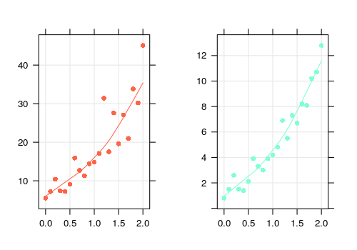

```r
print(xyplot(Y1 ~ x, data = da,
       type = c("p", "g", "smooth"), pch = 16,
             strip = strip.custom(bg = "white"),
       col = "tomato",
       xlab = "", ylab = ""),
     position = c(0,0, 0.5, 1), more = TRUE)

print(xyplot(Y2 ~ x, data = da,
             type = c("p", "g", "smooth"), pch = 16,
             strip = strip.custom(bg = "white"),
             col = "aquamarine",
             xlab = "", ylab = ""),
      position = c(0.5,0, 1, 1), more = TRUE)
```

_______________________________________________________________________

[interactive chart not shown]

### Estimating the Breakpoint

- For the estimation of the best breakpoint, we’ll test every value between a certain interval and look to the *LogLikelihood* of each adjusted model. The breakpoint that gives the bigger value for the LogLikelihood can be considered “the best one”:

```r
#------------------
g <- numeric(length = 20)

ll <- for (i in 1:20) {
  m <- i/10
  da$v <- with(da, ifelse(x <= m, 0, x - m))
  m1 <- lm(Y1 ~ x + v, data = da)
  g[i] <- AIC(m1)
}
which.min(g) # 1.9
```

```
[1] 19
```

```r
#-----------------
# Using the segmented package
s <-lm(Y1 ~ x, data = da)
o <- segmented(s, seg.Z=~x)

summary(o)
```

```
    ***Regression Model with Segmented Relationship(s)***

Call:
segmented.lm(obj = s, seg.Z = ~x)

Estimated Break-Point(s):
   Est. St.Err
 1.895  0.037

Meaningful coefficients of the linear terms:
            Estimate Std. Error t value Pr(>|t|)
(Intercept)    4.537      1.914   2.370   0.0299 *
x             13.144      1.817   7.234  1.4e-06 ***
U1.x         135.403     61.372   2.206       NA
---
Signif. codes:  0 '***' 0.001 '**' 0.01 '*' 0.05 '.' 0.1 ' ' 1

Residual standard error: 4.338 on 17 degrees of freedom
Multiple R-Squared: 0.857,  Adjusted R-squared: 0.8317

Convergence attained in 2 iterations with relative change 0
```

```r
#----------------
# Second Dataset
#---------------
g <- numeric(length = 20)

ll <- for (i in 1:20) {
  m <- i/10
  da$v <- with(da, ifelse(x <= m, 0, x - m))
  m1 <- lm(Y2 ~ x + v, data = da)
  g[i] <- AIC(m1)
}
which.min(g) # 1.5
```

```
[1] 15
```

```r
#-----------------
# Using the segmented package
s <-lm(Y2 ~ x, data = da)
o <- segmented(s, seg.Z=~x)
o$psi[2]
```

```
[1] 1.542088
```

## Model Expression

- When we have only one breakpoint, the model can be represented by:

$$\begin{align}
y = \beta_{0} + \beta_{1} x , & \quad x \leq c \\
y = \beta_{0} + \beta_{2} x + \theta (\beta_{1}-\beta_{2}), & \quad x > c
\end{align}$$

## Types of Segments

- We can also vary the behaviour of the line segments. Above, there is some examples of different situations:

### Different inclinations

$$\begin{align}
y = \beta_{0} + \beta_{1} x , & \quad x \leq c \\
y = \beta_{0} + \beta_{2} x , & \quad x > c
\end{align}$$

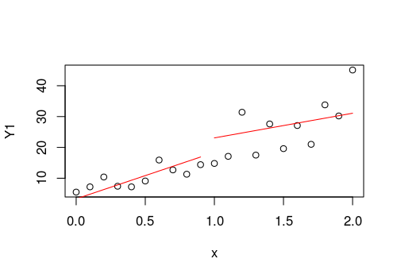

```r
m <- lm(Y1 ~ x, data = da)
da$pred <- predict(m)

#----------------------
plot(Y1 ~ x, data = da)
da <- da[order(da$Y1),]
with(subset(da, x < 1), lines(x, pred, col = "2"))
da$sec <- m$coefficients[2] + 8 * da$x
with(subset(da, x >= 1), lines(x, sec, col = "2"))
```

```r
#-----------------------
```

### Different intercepts

$$\begin{align}
y = \beta_{0} + \beta_{1} x , & \quad x \leq c \\
y = \beta_{2} + \beta_{1} x , & \quad x > c
\end{align}$$

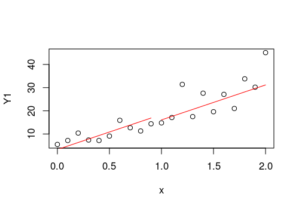

```r
plot(Y1 ~ x, data = da)
da <- da[order(da$x),]
with(subset(da, x < 1), lines(x, pred, col = "2"))
da$sec <- 1 + m$coefficients[2] * da$x
with(subset(da, x >= 1), lines(x, sec, col = "2"))
```

### Different intercepts and no inclination

$$\begin{align}
y = \beta_{0}, & \quad x \leq c \\
y = \beta_{1}, & \quad x > c
\end{align}$$

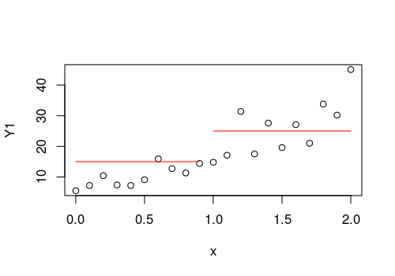

```r
plot(Y1 ~ x, data = da)
da <- da[order(da$x),]
da$c <- rep(15, nrow(da))
da$b <- rep(25, nrow(da))
with(subset(da, x < 1), lines(x, c, col = "2"))
with(subset(da, x >= 1), lines(x, b, col = "2"))
```

## Model Comparison

1. Linear Regression
2. Transformed Response Variable
3. Piecewise Regression
4. Polinomial Regression
5. Non-Linear Regression
6. Generalized Linear Regression

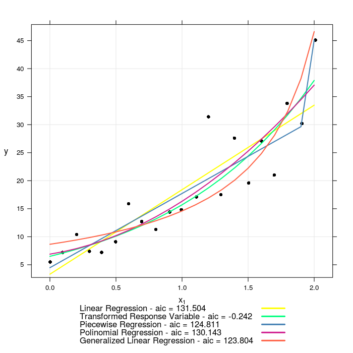

```r
m1 <- lm(Y1 ~ x, data = da)
m2 <- lm(log(Y1) ~ x, data = da)

da$v <- with(da, ifelse(x <= 1.9, 0, x - 1.9))
m3 <- lm(Y1 ~ x + v, data = da)
m4 <- lm(Y1  ~ poly(x, 2), data = da)

m6 <- glm(Y1 ~ x, family = "Gamma"(link = "inverse"),
          data = da)

#------------------------
pred <- data.frame(m1 = predict(m1), m2 = exp(predict(m2)),
                   m3 = predict(m3), m4 = predict(m4),
                   m6 = predict(m6, type = "response"))
pred$x <- da$x
pred <- pred[order(pred$x),]


xyplot(Y1 ~ x,
       pch = 16,
       jitter.x = TRUE,
       type = c("p", "g"),
       xlab = expression(x[1]),
       ylab = list(label = "y",
                   rot = 0),
       scales = list(y = list(tick.number = 8)),
       da, col = 1,
       key = list(space = "bottom",
                  cex.title = 1.15,
                  text = list(c(
                    paste0("Linear Regression - aic = ",
                           round(AIC(m1), 3)),
                    paste0("Transformed Response Variable - aic = ",
                           round(AIC(m2), 3)),
                    paste0("Piecewise Regression - aic = ",
                           round(AIC(m3), 3)),
                    paste0("Polinomial Regression - aic = ",
                           round(AIC(m4), 3)),
                    paste0("Generalized Linear Regression - aic = ",
                           round(AIC(m6), 3)))),
                  lines =
                    list(col = c("yellow",
                                 "springgreen", "steelblue",
                                 "violetred", "tomato"),
                               lwd = 3))
       )+
  as.layer(xyplot(m1 + m2 + m3 + m4 + m6  ~ x ,
                  data = pred, type = "l",
                  auto.key = TRUE,
                  col = c("yellow", "springgreen", "steelblue",
                          "violetred", "tomato"),
                  lwd = 2))
```

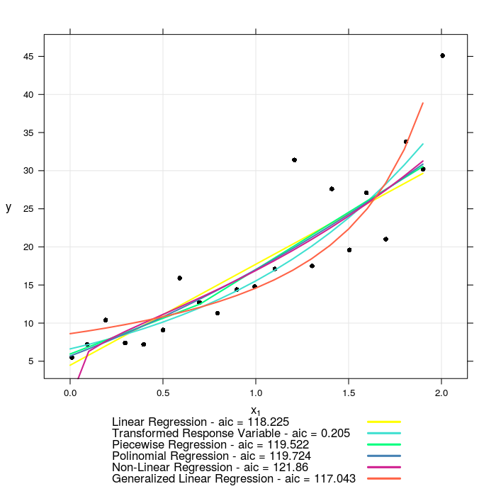

```r
#-------------------------------------------------------------
# Outlier Exclusion - for convergence of the Non-Linear Model
#------------------------------------------------------------

m1 <- lm(Y1 ~ x, data = da[-21,])
m2 <- lm(log(Y1) ~ x, data = da[-21,])

da$v <- with(da, ifelse(x <= 0.7, 0, x - 0.7))
m3 <- lm(Y1 ~ x + v, data = da[-21,])
m4 <- lm(Y1  ~ poly(x, 2), data = da[-21,])

# Incomplete Gamma Model
m5 <- nls(Y1 ~ (a*(x^b))*exp(-c*x),
          start = c(a = 10, b = 0.01, c = -0.9),
          data = da[-21,])

m6 <- glm(Y1 ~ x, family = "Gamma"(link = "inverse"),
          data = da[-21,])

#------------------------
pred <- data.frame(m1 = predict(m1), m2 = exp(predict(m2)),
                   m3 = predict(m3), m4 = predict(m4),
                   m5 = predict(m5),
                   m6 = predict(m6, type = "response"))
pred$x <- da[-21,]$x
pred <- pred[order(pred$x),]


xyplot(Y1 ~ x,
       pch = 16,
       jitter.x = TRUE,
       type = c("p", "g"),
       xlab = expression(x[1]),
       ylab = list(label = "y",
                   rot = 0),
       scales = list(y = list(tick.number = 8)),
       da, col = 1,
       key = list(space = "bottom",
                  cex.title = 1.15,
                  text = list(c(
                    paste0("Linear Regression - aic = ",
                           round(AIC(m1), 3)),
                    paste0("Transformed Response Variable - aic = ",
                           round(AIC(m2), 3)),
                    paste0("Piecewise Regression - aic = ",
                           round(AIC(m3), 3)),
                    paste0("Polinomial Regression - aic = ",
                           round(AIC(m4), 3)),
                    paste0("Non-Linear Regression - aic = ",
                           round(AIC(m5), 3)),
                    paste0("Generalized Linear Regression - aic = ",
                           round(AIC(m6), 3)))),
                  lines =
                    list(col = c("yellow", "turquoise",
                                 "springgreen", "steelblue",
                                 "violetred", "tomato"),
                               lwd = 3))
       )+
  as.layer(xyplot(m1 + m2 + m3 + m4 + m5 + m6  ~ x ,
                  data = pred, type = "l",
                  auto.key = TRUE,
                  col = c("yellow", "turquoise",
                          "springgreen", "steelblue",
                          "violetred", "tomato"),
                  lwd = 2))
```

**The AIC of the transformed response variable model is not comparable to others as it is.**

## Using more than one breakpoint

- When we have two breakpoints, for example, the model can be represented by:

$$\begin{align}
y = \beta_{0} + \beta_{1} x_{1} + \beta_{2} x_{2} + \beta_{3} x_{3},
\\
\\
x_{2}=\left\{
\begin{array}{ll}
x_{1}-c_{1}, \quad c_{1} \leq x\\
0, cc. \\
\end{array}
\right.
\\
x_{3}=\left\{
\begin{array}{ll}
x_{1}-c_{2}, \quad c_{2} \leq x\\
0, cc. \\
\end{array}
\right.
\end{align}$$

```r
#----------------------------------------------------------------
da$x2 <- with(da, ifelse(x < 0.5, 0, x-0.5))
da$x3 <- with(da, ifelse(x < 0.5 | x >= 1.3, 0, x-1.3))
da$x4 <- with(da, ifelse(x >= 1.3, 0, x-1.3))

m1 <- lm(Y1 ~ x + x2 + x3, data = da) # With interval
m2 <- lm(Y1 ~ x + x2 + x4, data = da) # Without interval
logLik(m1); logLik(m2)
```

```
'log Lik.' -61.6259 (df=5)
```

```
'log Lik.' -61.38696 (df=5)
```

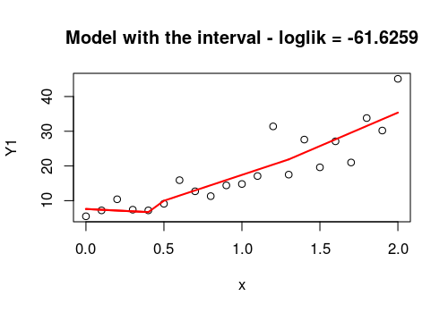

```r
plot(Y1 ~ x, data = da,
     main = paste0("Model with the interval - loglik = ",
                   round(logLik(m1), 4)))
da$pred1 <- predict(m1)
with(subset(da, x < 0.5), lines(x, pred1, col = "2", lwd = 2))
with(subset(da,  0.5 > x | x <= 1.3),
     lines(x, pred1, col = "2", lwd = 2))
with(subset(da, x >= 1.3), lines(x, pred1, col = "2", lwd = 2))
```

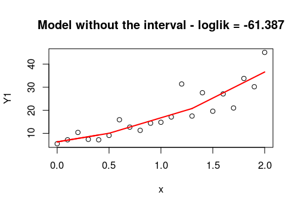

```r
plot(Y1 ~ x, data = da, main =
       paste0("Model without the interval - loglik = ",
              round(logLik(m2), 3)))
da$pred2 <- predict(m2)
with(subset(da, x < 0.5), lines(x, pred2, col = "2", lwd = 2))
with(subset(da,  0.5 > x | x <= 1.3),
     lines(x, pred2, col = "2", lwd = 2))
with(subset(da, x >= 1.3), lines(x, pred2, col = "2", lwd = 2))
```